# Exploratory Analysis on Users

2019-02-04

This document presents exploratory analysis on the number of users active in the general subforum (r/politics) between June 1, 2016 and December 31, 2016. The dataset used for the analysis here is an author-level dataset in which for each author I report the count of comments in each of the four subreddits (reported in the variables pol_count, trump_count, clinton_count, sanders_count) and the date of the first comment (reported in the *_since variables).

**Executive summary**: 248,192 different authors have posted more than 2 comments in the r/politics forum in our timeframe. We can credibly identify 35,199 users as active[^1] Trump supporters based on their activity on the partisan forums and 4,423 users as active Clinton supporters. Among Sanders supporters, it is likely that after the primaries ended more of them shifted to supporting Trump rather than supporting Clinton. The distributions of start of activity of the users (i.e. the distributions of date of first comments) on the general, Trump, and Clinton subforums are broadly similar (section 3).

# 1 Number of comments and authors

The following table summarizes the number of comments by authors in the four subreddits of interest (f.e. the variable “pol_count” counts the number of comments of one author on the general subforum).

The column “Valid” reports the number of non missing observations. Since this dataset is made of all users active in r/politics the variable pol_count is never missing by construction.

The variable trump_count is non-missing in 88,313 cases, which means that 88,313 users on r/politics (23.92% of the total) were also active on r/The_Donald. For Clinton it is 19,301 users and for Sanders it is 34,905.

```r
count_vars = c('pol_count','trump_count','clinton_count','sanders_count')

counts = df[count_vars]

dfSummary(df, graph.col=FALSE, varnumbers=FALSE, na.col = FALSE, plain.ascii = FALSE ,style = "grid")
```

| Variable | Stats / Values | Freqs (% of Valid) | Valid |
| --- | --- | --- | --- |
| author [character] | 1. __________________99 2. __________________d 3. _________________– 4. ________________mane 5. _____________what 6. ____________13 7. ___________— 8. __________-*-*______ 9. __________— 10. _________… | 1 ( 0.0%) 1 ( 0.0%) 1 ( 0.0%) 1 ( 0.0%) 1 ( 0.0%) 1 ( 0.0%) 1 ( 0.0%) 1 ( 0.0%) 1 ( 0.0%) 1 ( 0.0%) 369137 (100.0%) | 369147 (100%) |
| pol_count [numeric] | mean (sd) : 35.66 (2027.46) min < med < max : 1 < 3 < 1215692 IQR (CV) : 10 (56.86) | 2084 distinct values | 369147 (100%) |
| pol_since [Date] | min : 2016-06-01 med : 2016-08-31 max : 2016-12-31 range : 6m 30d | 214 distinct val. | 369147 (100%) |
| trump_count [numeric] | mean (sd) : 66.18 (3176.9) min < med < max : 1 < 4 < 940973 IQR (CV) : 19 (48) | 1617 distinct values | 88313 (23.92%) |
| trump_since [Date] | min : 2016-06-01 med : 2016-08-06 max : 2016-12-31 range : 6m 30d | 214 distinct val. | 88313 (23.92%) |
| clinton_count [numeric] | mean (sd) : 35.77 (1008.06) min < med < max : 1 < 2 < 137712 IQR (CV) : 5 (28.18) | 560 distinct values | 19301 (5.23%) |
| clinton_since [Date] | min : 2016-06-01 med : 2016-09-06 max : 2016-12-31 range : 6m 30d | 214 distinct val. | 19301 (5.23%) |
| sanders_count [numeric] | mean (sd) : 12.45 (441.45) min < med < max : 1 < 2 < 82120 IQR (CV) : 5 (35.47) | 345 distinct values | 34905 (9.46%) |
| sanders_since [Date] | min : 2016-06-01 med : 2016-06-17 max : 2016-12-30 range : 6m 29d | 82 distinct val. | 34905 (9.46%) |

The following table allows exploration of number of authors by activity, in the different subreddits. For each row, the variable $\text{authors_}j$ reports the number of authors who have posted more than $x$ comments on the forum $j$, where $x$ is reported in the column “Threshold”.

```r
print(counts_byAct, n = 50)
```

```
## # A tibble: 50 x 5
##    Threshold authors_politics authors_trump authors_clinton authors_sanders
##        <dbl>            <int>         <int>           <int>           <int>
##  1         1           369147         88313           19301           34905
##  2         2           248192         64848           11468           22384
##  3         3           199292         53801            8495           16886
##  4         4           170488         47023            6965           13640
##  5         5           150865         42304            5912           11482
##  6         6           136306         38925            5182            9909
##  7         7           125029         36226            4702            8678
##  8         8           115947         34063            4288            7738
##  9         9           108410         32278            3981            7014
## 10        10           101983         30706            3730            6358
## 11        11            96434         29349            3527            5830
## 12        12            91600         28175            3354            5376
```

[output cut: 38 more lines]

# 2 Overlapping users

In order to tag users as supporters of one candidate or “independent” voters, we analyze their activity on the partisan forums. Ideally, each voter in the politics forum that supports one candidate is active only on the partisan forum of his candidate.

Yet, some users are active both on the general forum and also on more than one partisan forum. The following tables analyze the number of overlapping users. The analysis is repeated first for Trump supporters and then for Clinton supporters. For each candidate, the sample of supporters has been restricted to users who posted at least 5 comments on the partisan subreddit.

## 2.1 Trump

The table reports descriptives for dummies indicating whether the user is active:

- on any other partisan forums (`active_on_others`)
- on one specific partisan forums (`active_on_clinton`, `active_on_sanders`)

Then for each other candidate it presents descriptive of the following ratios:

$$\text{ratio_Trump_}j = \frac{\text{# of comm. on Trump subreddit}}{\text{# of comm. on Trump sub.} + \text{# of comm. on partisan sub. of candidate } j}$$

where $j$ is Clinton, Sanders, or Clinton+Sanders.

The ratio captures how many comments, among the total comments posted on the partisan forums, one users posts in the Trump forum (i.e. ratio_Trump_Clinton is the number of comments posted on the Trump forum over the total number of comments posted on the Trump forum and on the Clinton forum). If it is big enough it then means that most of the comments are posted in the Trump forum and hence that it is likely that the user is a Trump supporter.

**Conclusion**: 42,304 users active in r/politics are also active in r/The_Donald and have posted at least 5 comments. However, 11,618 of those were active also in other partisan forums. Among users active in other partisan forums, however, 4,513 wrote at least 95% of their comments on the Trump forum and can hence be classified as Trump supporters who were likely to go to other partisan forums just in hostile ways.

To conclude, this leaves us with a sample of 35,199 who we can credibly classify as Trump supporters.

| No | Variable | Stats / Values | Freqs (% of Valid) | Text Graph |
| --- | --- | --- | --- | --- |
| 1 | active_on_others [numeric] | mean (sd) : 0.27 (0.45) min < med < max : 0 < 0 < 1 IQR (CV) : 1 (1.63) | 0 : 30686 (72.5%) 1 : 11618 (27.5%) | IIIIIIIIIIIIIIII IIIIII |
| 2 | active_on_clinton [numeric] | mean (sd) : 0.12 (0.33) min < med < max : 0 < 0 < 1 IQR (CV) : 0 (2.71) | 0 : 37221 (88.0%) 1 : 5083 (12.0%) | IIIIIIIIIIIIIIII II |
| 3 | active_on_sanders [numeric] | mean (sd) : 0.19 (0.4) min < med < max : 0 < 0 < 1 IQR (CV) : 0 (2.03) | 0 : 34056 (80.5%) 1 : 8248 (19.5%) | IIIIIIIIIIIIIIII III |
| 4 | ratio_trump_clinton [numeric] | mean (sd) : 0.99 (0.07) min < med < max : 0 < 1 < 1 IQR (CV) : 0 (0.07) | 1435 distinct values |  |
| 5 | ratio_trump_clinton_over95 [numeric] | mean (sd) : 0.94 (0.24) min < med < max : 0 < 1 < 1 IQR (CV) : 0 (0.26) | 0 : 2685 ( 6.3%) 1 : 39619 (93.7%) | I IIIIIIIIIIIIIIII |
| 6 | ratio_trump_clinton_over90 [numeric] | mean (sd) : 0.95 (0.21) min < med < max : 0 < 1 < 1 IQR (CV) : 0 (0.22) | 0 : 1910 ( 4.5%) 1 : 40394 (95.5%) | IIIIIIIIIIIIIIII |
| 7 | ratio_trump_sanders [numeric] | mean (sd) : 0.97 (0.11) min < med < max : 0.01 < 1 < 1 IQR (CV) : 0 (0.11) | 2460 distinct values |  |
| 8 | ratio_trump_sanders_over95 [numeric] | mean (sd) : 0.88 (0.33) min < med < max : 0 < 1 < 1 IQR (CV) : 0 (0.37) | 0 : 5135 (12.1%) 1 : 37169 (87.9%) | II IIIIIIIIIIIIIIII |
| 9 | ratio_trump_sanders_over90 [numeric] | mean (sd) : 0.91 (0.29) min < med < max : 0 < 1 < 1 IQR (CV) : 0 (0.32) | 0 : 3829 ( 9.0%) 1 : 38475 (91.0%) | I IIIIIIIIIIIIIIII |
| 10 | ratio_trump_others [numeric] | mean (sd) : 0.96 (0.13) min < med < max : 0 < 1 < 1 IQR (CV) : 0.01 (0.13) | 2973 distinct values |  |
| 11 | ratio_trump_others_over95 [numeric] | mean (sd) : 0.83 (0.37) min < med < max : 0 < 1 < 1 IQR (CV) : 0 (0.45) | 0 : 7105 (16.8%) 1 : 35199 (83.2%) | III IIIIIIIIIIIIIIII |
| 12 | ratio_trump_others_over90 [numeric] | mean (sd) : 0.87 (0.33) min < med < max : 0 < 1 < 1 IQR (CV) : 0 (0.38) | 0 : 5337 (12.6%) 1 : 36967 (87.4%) | II IIIIIIIIIIIIIIII |

## 2.2 Clinton

The same analysis is repeated for Clinton supporters.

**Conclusion**: 5,912 users active in r/politics are also active in r/hillaryclinton and have posted at least 5 comments. However, 3,094 of those were active also in other partisan forums. 1,815 on the Trump forum. Focusing on the latter group, 501 wrote at least 95% of their comments on the Clinton forum and can hence be classified as Clinton supporters who were likely to go to the Trump forum just in hostile ways.

To conclude, this leaves us with a sample of 4,423 users active in r/politics who we can credibly classify as Clinton supporters. Repeating this exercise fixing the threshold at 2 comments posted at least leaves us with 7,315 users (calculations and data not shown).

| No | Variable | Stats / Values | Freqs (% of Valid) | Text Graph |
| --- | --- | --- | --- | --- |
| 1 | active_on_others [numeric] | mean (sd) : 0.57 (0.5) min < med < max : 0 < 1 < 1 IQR (CV) : 1 (0.87) | 0 : 4945 (43.1%) 1 : 6523 (56.9%) | IIIIIIIIIIII IIIIIIIIIIIIIIII |
| 2 | active_on_trump [numeric] | mean (sd) : 0.39 (0.49) min < med < max : 0 < 0 < 1 IQR (CV) : 1 (1.25) | 0 : 6989 (60.9%) 1 : 4479 (39.1%) | IIIIIIIIIIIIIIII IIIIIIIIII |
| 3 | active_on_sanders [numeric] | mean (sd) : 0.32 (0.47) min < med < max : 0 < 0 < 1 IQR (CV) : 1 (1.45) | 0 : 7781 (67.8%) 1 : 3687 (32.1%) | IIIIIIIIIIIIIIII IIIIIII |
| 4 | ratio_clinton_trump [numeric] | mean (sd) : 0.77 (0.36) min < med < max : 0 < 1 < 1 IQR (CV) : 0.41 (0.46) | 1322 distinct values |  |
| 5 | ratio_clinton_trump_over95 [numeric] | mean (sd) : 0.64 (0.48) min < med < max : 0 < 1 < 1 IQR (CV) : 1 (0.75) | 0 : 4153 (36.2%) 1 : 7315 (63.8%) | IIIIIIIII IIIIIIIIIIIIIIII |
| 6 | ratio_clinton_trump_over90 [numeric] | mean (sd) : 0.65 (0.48) min < med < max : 0 < 1 < 1 IQR (CV) : 1 (0.73) | 0 : 3978 (34.7%) 1 : 7490 (65.3%) | IIIIIIII IIIIIIIIIIIIIIII |
| 7 | ratio_clinton_sanders [numeric] | mean (sd) : 0.86 (0.26) min < med < max : 0 < 1 < 1 IQR (CV) : 0.14 (0.3) | 1025 distinct values |  |
| 8 | ratio_clinton_sanders_over95 [numeric] | mean (sd) : 0.71 (0.45) min < med < max : 0 < 1 < 1 IQR (CV) : 1 (0.64) | 0 : 3305 (28.8%) 1 : 8163 (71.2%) | IIIIII IIIIIIIIIIIIIIII |
| 9 | ratio_clinton_sanders_over90 [numeric] | mean (sd) : 0.73 (0.44) min < med < max : 0 < 1 < 1 IQR (CV) : 1 (0.6) | 0 : 3054 (26.6%) 1 : 8414 (73.4%) | IIIII IIIIIIIIIIIIIIII |
| 10 | ratio_clinton_others [numeric] | mean (sd) : 0.68 (0.37) min < med < max : 0 < 0.9 < 1 IQR (CV) : 0.67 (0.55) | 1875 distinct values |  |
| 11 | ratio_clinton_others_over95 [numeric] | mean (sd) : 0.47 (0.5) min < med < max : 0 < 0 < 1 IQR (CV) : 1 (1.05) | 0 : 6028 (52.6%) 1 : 5440 (47.4%) | IIIIIIIIIIIIIIII IIIIIIIIIIIIII |
| 12 | ratio_clinton_others_over90 [numeric] | mean (sd) : 0.5 (0.5) min < med < max : 0 < 1 < 1 IQR (CV) : 1 (1) | 0 : 5729 (50.0%) 1 : 5739 (50.0%) | IIIIIIIIIIIIIII IIIIIIIIIIIIIIII |

## 2.3 Excursus: Former Sanders supporters

The dataset offers an interesting perspective on Sanders supporters.

As one can see from the variables active_on_trump and active_on_clinton, among Sanders supporters 4,639 commented on the Trump forum and 2,641 commented on the Clinton forum. Furthermore, by analyzing the ratios one sees that the ratio_sanders_trump is much lower on average than the ratio_sanders_clinton (0.53 vs. 0.68). This suggests that Sanders supporters that also wrote on the Trump forum were on average more active on the Trump forum compared to how active on the Clinton forum were the Sanders supporters that wrote on the Clinton forum. This suggests that there is room for studying this shift away from the Sanders forum, also by leveraging the time horizons in which those shift happened. Based on this data, the prior is that Sanders supporters were much more likely to become Trump supporters rather than Clinton ones, despite the clear policy and ideology differences with Trump.

Ideally, one could tag this voters as identifying with an extremist/anti-establishment group rather than with their ideological group. Upon doing this, it is possible to leverage text analysis and understand what concerned more these voters compared to the rest.

| No | Variable | Stats / Values | Freqs (% of Valid) | Text Graph | Valid | Missing |
| --- | --- | --- | --- | --- | --- | --- |
| 1 | active_on_trump [numeric] | mean (sd) : 1 (0) min < med < max : 1 < 1 < 1 IQR (CV) : 0 (0) | 1 : 4639 (100.0%) | IIIIIIIIIIIIIIII | 4639 (40.4%) | 6843 (59.6%) |
| 2 | active_on_clinton [numeric] | mean (sd) : 1 (0) min < med < max : 1 < 1 < 1 IQR (CV) : 0 (0) | 1 : 2641 (100.0%) | IIIIIIIIIIIIIIII | 2641 (23%) | 8841 (77%) |
| 3 | ratio_sanders_trump [numeric] | mean (sd) : 0.53 (0.35) min < med < max : 0 < 0.6 < 1 IQR (CV) : 0.69 (0.65) | 1820 distinct values |  | 4639 (40.4%) | 6843 (59.6%) |
| 4 | ratio_sanders_clinton [numeric] | mean (sd) : 0.68 (0.29) min < med < max : 0 < 0.81 < 1 IQR (CV) : 0.41 (0.42) | 886 distinct values |  | 2641 (23%) | 8841 (77%) |

# 3 Dynamics of activity

The graph below reports the density of four variables, one for each subforum, which indicate the first day in which a given user commented in the subforum. As it is possible to see, users on the Sanders forum became active there much before the others, while other users followed similar patterns across the different groups.

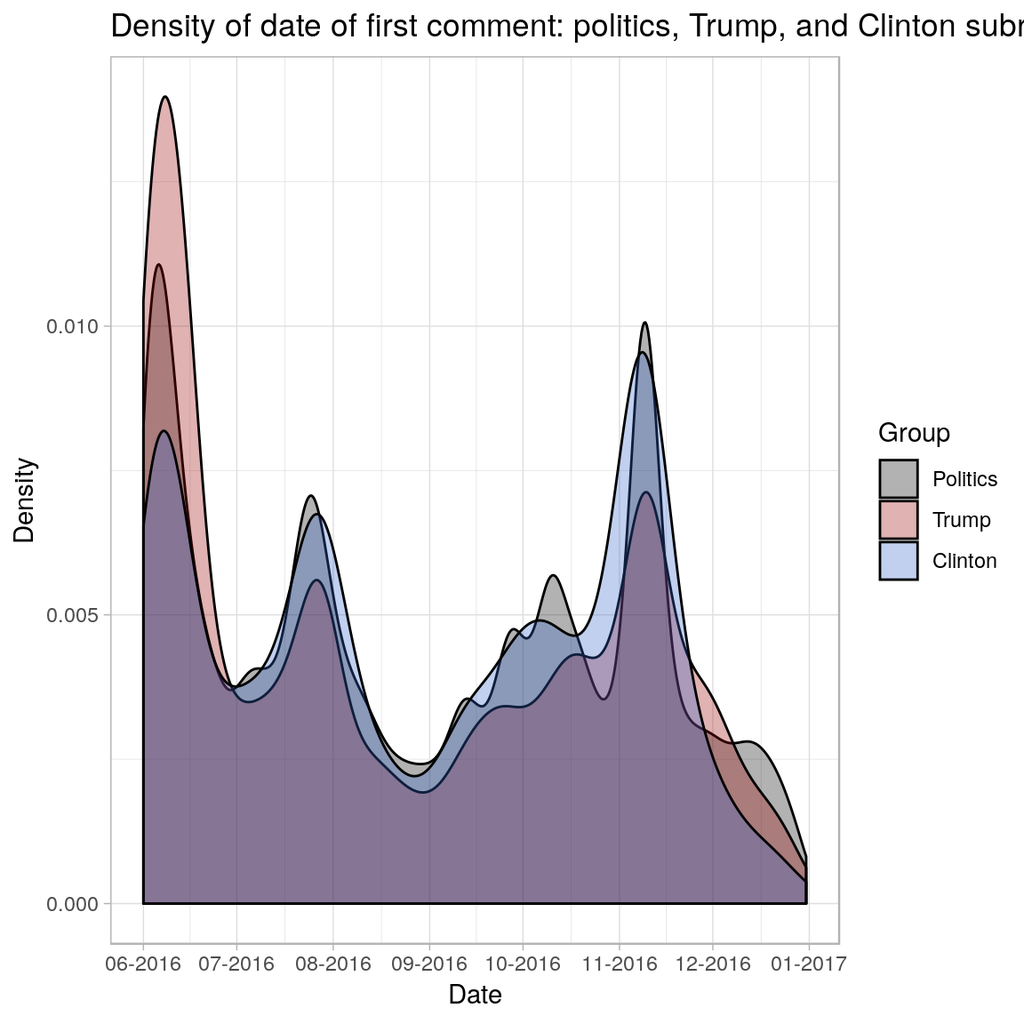

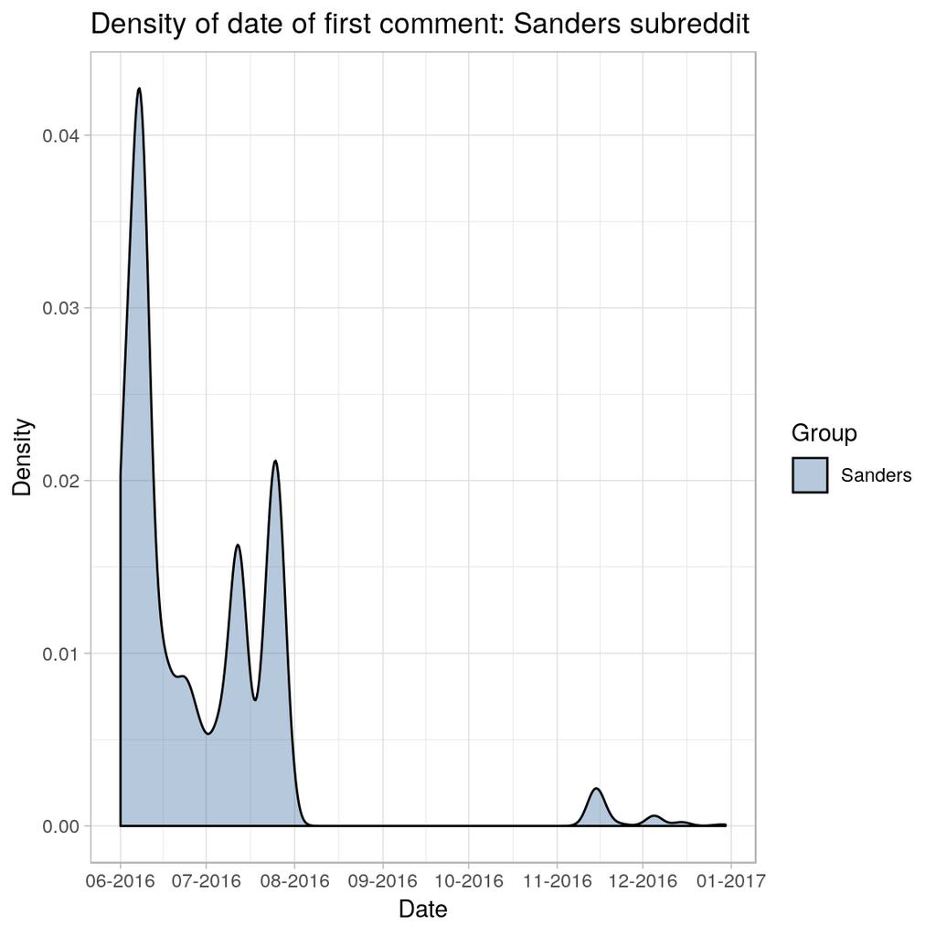

[^1]: More than 5 comments posted.